# Single locus simulations

```r
library(devtools)
library(tidyverse)
load_all()
load('../simdata/sl-covs.Rdata')
```

Parameterization notes: In my R sims, we use $w = 1 + \alpha g$ where $\alpha$ is the effect size and $g$ is the gene count for the selected allele.

## Additive Genetic Variation in a Single Locus Model

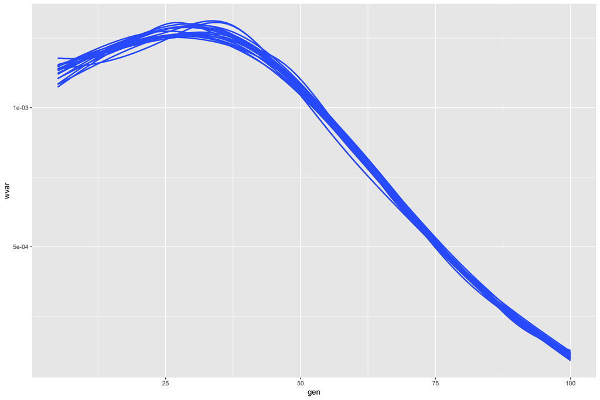

```r
sl_res %>% filter(alpha == 0.1, rec_frac > 0.4) %>%
  unnest(stats) %>% filter(gen > 4) %>%
  modelr::bootstrap(20) %>%
  mutate(strap=map(strap, as_tibble)) %>% unnest(strap) %>%
  ggplot(aes(gen, wvar, group=.id)) + geom_smooth(se=FALSE)
```

Compare to conditioning on initial allele frequency:

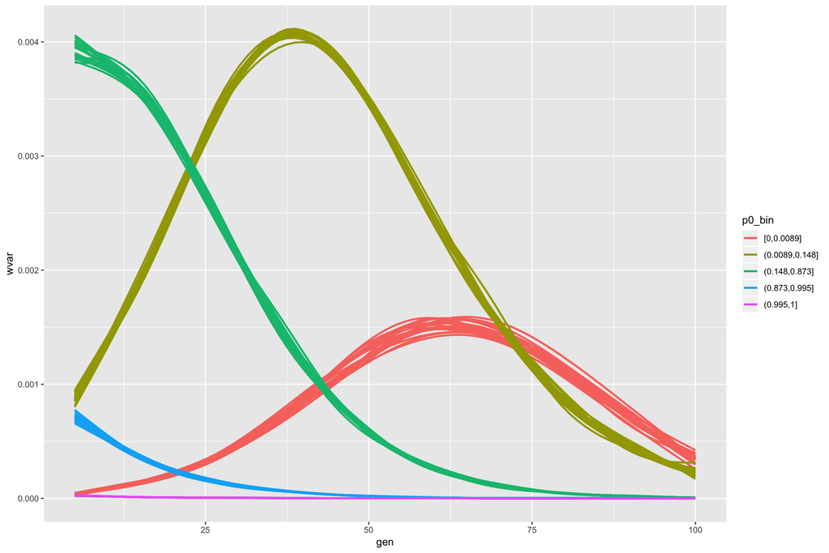

```r
get_init_freq <- function(x) x$sel_freqs[1]


sl_wvar_trajs <- sl_res %>% filter(alpha == 0.1, rec_frac > 0.4) %>%
  mutate(p0=map_dbl(res, get_init_freq)) %>%
  unnest(stats) %>% filter(gen > 4) %>%
  mutate(p0_bin=cut_number(p0, 5)) %>%
  #mutate(p0_bin=cut(p0, c(0, 0.05, 0.1, 0.3, 0.7, 0.9, 0.095, 1))) %>%
  group_by(p0_bin) %>%
  do(rs=modelr::bootstrap(., 20)) %>% unnest(rs) %>%
  mutate(strap=map(strap, as_tibble)) %>%
  unnest(strap)


sl_wvar_trajs %>% ggplot(aes(gen, wvar, group=interaction(.id, p0_bin), color=p0_bin)) +
  geom_smooth(se=FALSE)
```

```r
# write data for plot
devtools::use_data(sl_wvar_trajs, overwrite=TRUE)
write_tsv(sl_wvar_trajs, '../data/sl_wvar_trajs.tsv')
```

This explains why we see $V_A(t)$ has a hump above.

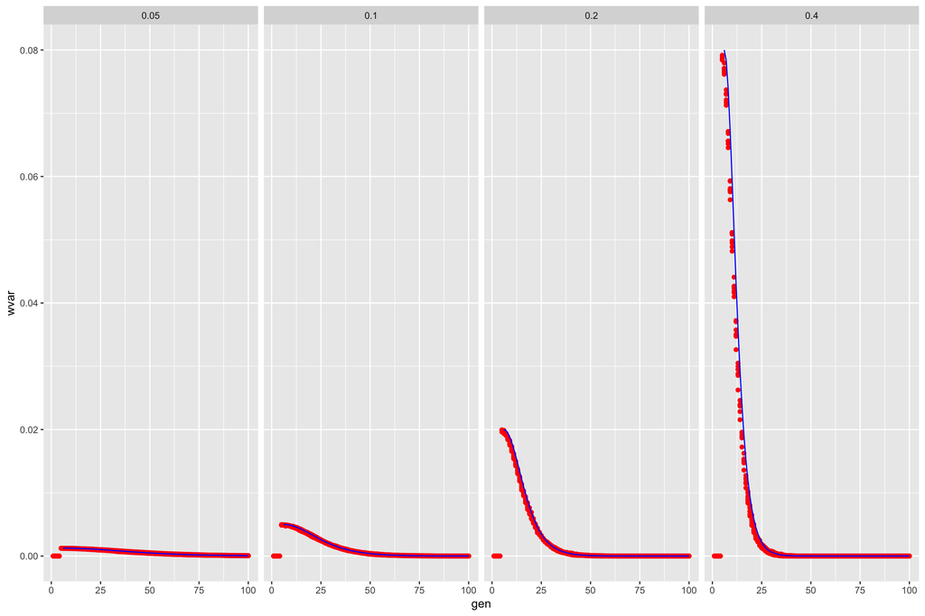

```r
# condition on intermediate freq
sl_res_int <- sl_res %>% select(-covs) %>%
              mutate(init_freq=map_dbl(res, ~ .$sel_freqs[1])) %>%
              filter(abs(init_freq - 0.5) < 0.1)

# empirical variances
vark_int <- sl_res_int %>%
          unnest(stats) %>%
          group_by(N, alpha, rec_frac, gen) %>%
          summarize(wvar=mean(wvar)) %>%
          ungroup()

ngens <- max(vark_int$gen)


theory_vark <-
  vark_int %>% select(N, alpha, rec_frac) %>%
                 distinct(.keep_all=TRUE) %>%
                 mutate(va=map(alpha, ~ sl_var_traj(p0=0.5, ngens, s=.*2)))  %>%
                 unnest(va) %>% mutate(gen=gen+5)


all_vark_int <- vark_int %>% left_join(theory_vark)

all_vark_int %>%
  ggplot() + geom_point(aes(gen, wvar), color='red') + geom_line(aes(gen, theory_va), color='blue') + facet_grid(~alpha)
```

Compare to the case where we don’t condition on intermediate frequency:

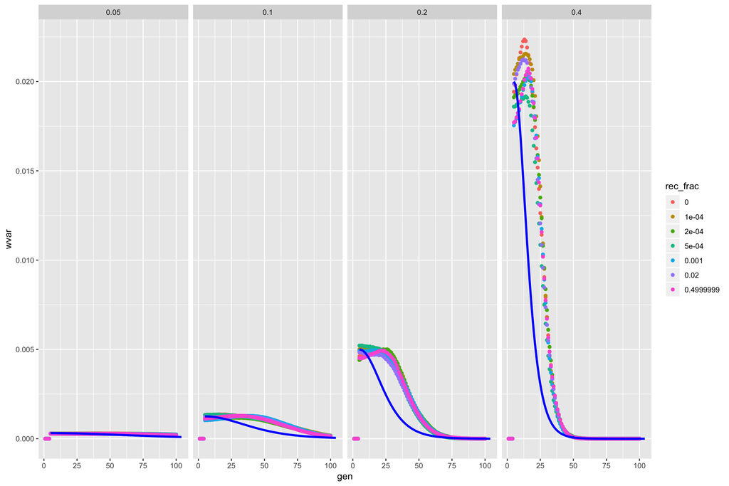

```r
# empirical variances
vark <- sl_res %>%
          unnest(stats) %>%
          group_by(N, alpha, rec_frac, gen) %>%
          summarize(wvar=mean(wvar), kvar=mean(kvar), wbar=mean(wbar)) %>%
          ungroup()

ngens <- max(vark$gen)
theory_vark <-
  vark %>% select(N, alpha, rec_frac) %>%
                 distinct(.keep_all=TRUE) %>%
                 mutate(va=map(alpha, ~ sl_var_traj(p0=0.5, ngens, s=.)))  %>%
                 unnest(va) %>% mutate(gen=gen)

all_vark <- vark %>% left_join(theory_vark)


all_vark %>% mutate(kvar=(kvar-2)/2) %>%
  mutate(rec_frac=as.factor(rec_frac)) %>%
  ggplot() + geom_point(aes(gen, wvar, color=rec_frac)) + geom_line(aes(gen+4, theory_va), color='blue', size=1.2) + facet_grid(~ alpha)
```

## Calculate Covariances

First we calculate the covariances. First, recall that there are two sites per simulation: the selected site and the neutral site. We can calculate the covariance by either calculating it on a single site as $\Delta p_t \Delta p_s$, and then average the covariances across replicates. Or, we can bind each of the neutral sites and calculate the covariance, calculating the covariance by averaging across replicates (this essentially treats each replicate as a different loci). The former is much, much nosier – likely due to how fixations are handled (and perhaps because the mean isn’t subtracted off). Here, we reshape the neutral allele frequencies:

```r
sl_freqs <- sl_res %>% select(-covs, -stats) %>%
              mutate(neut_freqs = map(res, get_neut_freqs)) %>%
              select(-res) %>%
              group_by(N, alpha, rec_frac) %>% nest() %>%
              # reshape neutral allele frequencies, binding
              # replicates into a single matrix
              # that we can then calculate covariance over
              mutate(freqs=map(data, reshape_neut_freqs))
```

We calculate the temporal covariances on all of these replicates reshaped, such that the covariance is averaging across replicates.

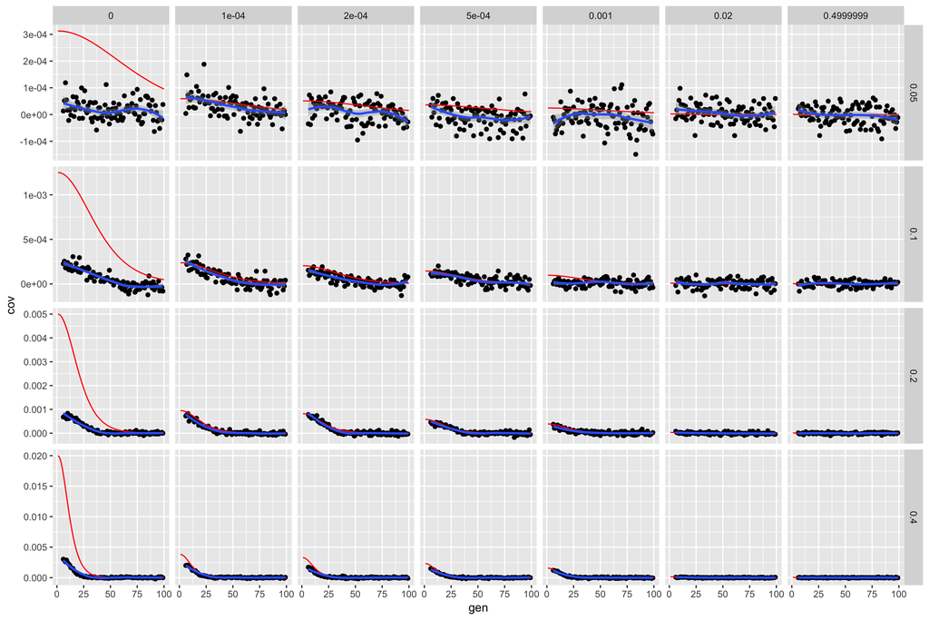

```r
sl_covs <- sl_freqs %>%
  mutate(covs=map(freqs, ~ temp_cov(., as_df=TRUE, remove_fixed=FALSE))) %>%
             unnest(covs)

pred <- all_vark %>% ungroup() %>% mutate(N=as.integer(as.character(N)),
            cov=pmap_dbl(list(rec_frac, gen-5, theory_va, N), sl_analytic_cov))  %>%
           mutate(N=factor('1000'))

rec_params <- c(1e-4, 5e-4, 0.02)
alpha_params <- c(0.05, 0.1, 0.2)
covs5 <- sl_covs %>% filter(t1 > t0, t0 == 5,
                            # $alpha %in% alpha_params,
                            #rec_frac %in% rec_params,
                            ) %>% mutate(gen=t1) %>%
           mutate(N=as.factor(N))


covs5 %>%
ggplot(aes(gen, cov)) + geom_point() +
  geom_line(data=pred, aes(gen, cov), color='red') +
  geom_smooth() +
  facet_grid(alpha~rec_frac, scales='free_y')
```

This shows that we get good fits, but at a certain point (high $\alpha$, low $r$), we end up with interference.

We write the files necessary to produce the supplementary figure to file:

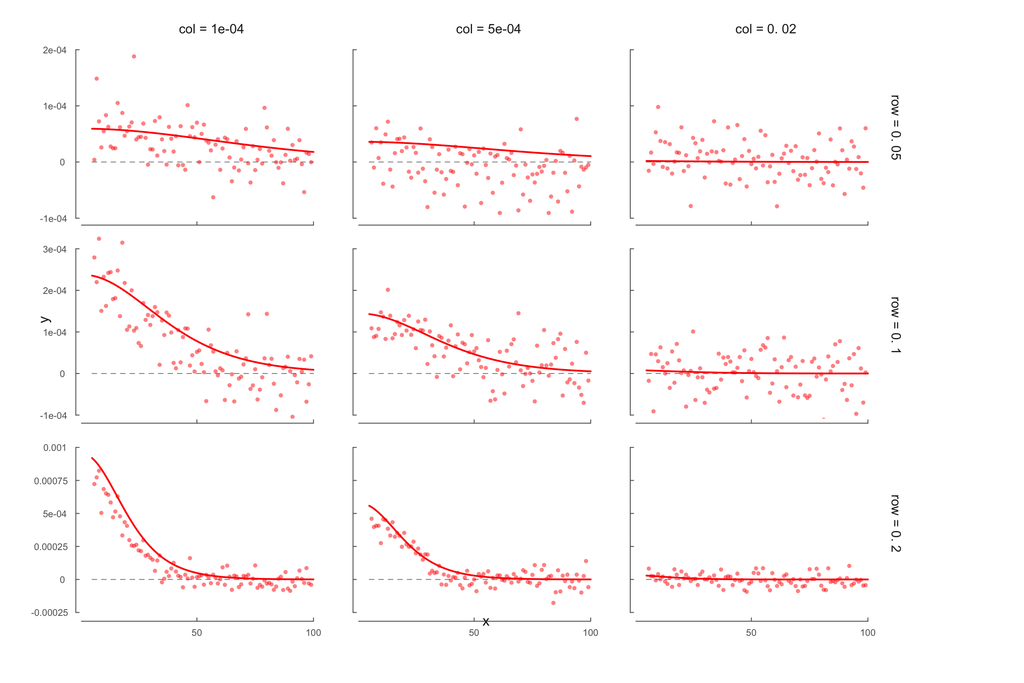

```r
sl_pd5f <- filter(covs5, alpha %in% alpha_params, rec_frac %in% rec_params)
# only keep predictions when gen > 5, when selection is turned on.
# our V_A just looks at sel. allele freq, not when sel. is turned
# on so this is needed:
sl_predf <- filter(pred, alpha %in% alpha_params, rec_frac %in% rec_params, gen >= 5)


# tables and Rda files for plots:
write_tsv(sl_pd5f, '../data/sl_pd5f.tsv')
write_tsv(sl_predf, '../data/sl_predf.tsv')
devtools::use_data(sl_pd5f, overwrite=TRUE)
devtools::use_data(sl_predf, overwrite=TRUE)

panel_plot(sl_pd5f, sl_predf, gen, cov, alpha, rec_frac, N, pch_cex=1)
```